### Summary

This analysis considers the Weight Lifting Exercise Dataset and fits a random forest model to predict whether a dumb bell lift exercise was conducted properly or not, based on the various measurements from sensors attached the individual and the dumb bell. (http://groupware.les.inf.puc-rio.br/har)

### Clean Data

Before fitting the model, the data must be downloaded, split into training and testing sets, and cleaned. The Weight Lifting Exercise Dataset can be downloaded here: https://d396qusza40orc.cloudfront.net/predmachlearn/pml-training.csv.

```r
# call libraries
library(caret)
library(car)

# read in data
setwd("C:/Users/sdevine/Desktop/pml_project")
full_training <- read.csv("pml-training.csv")
full_testing <- read.csv("pml-testing.csv")

# split full_training into training and testing datasets
in_train <- createDataPartition(full_training$classe, p = .7, list = FALSE)
training <- full_training[in_train, ]
testing <- full_training[-in_train, ]

# remove non-predictor variables
training1 <- training[ , -1]
training1 <- training1[ , -c(2:6)]

testing1 <- testing[ , -1]
testing1 <- testing1[ , -c(2:6)]

# remove columns with NA
training1 <- training1[ , colSums(is.na(training1)) == 0]

testing1 <- testing1[ , colSums(is.na(testing1)) == 0]

# remove rows with #DIV/0!
training2 <- training1
rownames(training2) <- NULL
remove <- rowSums(training2 == "#DIV/0!")
remove2 <- which(remove != 0)
training3 <- training2[-remove2, ]

testing2 <- testing1
rownames(testing2) <- NULL
remove <- rowSums(testing2 == "#DIV/0!")
remove2 <- which(remove != 0)
testing3 <- testing2[-remove2, ]

# convert numeric-looking factors to numeric
training4 <- training3
training4 <- as.data.frame(lapply(training4[ , -c(1, 87)], function(x) as.numeric(as.character(x))))
training4 <- cbind(training3[ , 1], training4)
training4 <- cbind(training4, training3[ , 87])
names(training4)[87] <- "classe"
names(training4)[1] <- "user_name"

testing4 <- testing3
testing4 <- as.data.frame(lapply(testing4[ , -c(1, 87)], function(x) as.numeric(as.character(x))))
testing4 <- cbind(testing3[ , 1], testing4)
testing4 <- cbind(testing4, testing3[ , 87])
names(testing4)[87] <- "classe"
names(testing4)[1] <- "user_name"

# remove columns that now consist only of NA after #DIV/0! rows removed
training5 <- training4
na <- colSums(is.na(training5))
remove3 <- which(na != 0)
training5 <- training5[ , -remove3]

testing5 <- testing4
na <- colSums(is.na(testing5))
remove3 <- which(na != 0)
testing5 <- testing5[ , -remove3]
```

### Exploratory data analysis

Once the data have been cleaned, some exploratory analysis can help visualize the training dataset.

Here is a summary of the training dataset:

```r
summary(training5)
```

```
##     user_name      roll_belt        pitch_belt          yaw_belt
##  adelmo  :2667   Min.   :-28.90   Min.   :-54.9000   Min.   :-180.00
##  carlitos:2144   1st Qu.:  1.10   1st Qu.:  1.8700   1st Qu.: -88.30
##  charles :2423   Median :114.00   Median :  5.3200   Median : -12.10
##  eurico  :2053   Mean   : 64.75   Mean   :  0.3818   Mean   : -11.01
##  jeremy  :2330   3rd Qu.:123.00   3rd Qu.: 15.4000   3rd Qu.:  12.90
##  pedro   :1821   Max.   :162.00   Max.   : 60.2000   Max.   : 179.00
##  total_accel_belt  gyros_belt_x        gyros_belt_y       gyros_belt_z
##  Min.   : 0.00    Min.   :-1.040000   Min.   :-0.64000   Min.   :-1.4600
##  1st Qu.: 3.00    1st Qu.:-0.030000   1st Qu.: 0.00000   1st Qu.:-0.2000
##  Median :17.00    Median : 0.030000   Median : 0.02000   Median :-0.1100
##  Mean   :11.35    Mean   :-0.006672   Mean   : 0.03951   Mean   :-0.1323
##  3rd Qu.:18.00    3rd Qu.: 0.110000   3rd Qu.: 0.11000   3rd Qu.:-0.0200
##  Max.   :28.00    Max.   : 2.220000   Max.   : 0.64000   Max.   : 1.6200
##   accel_belt_x      accel_belt_y     accel_belt_z    magnet_belt_x
##  Min.   :-120.00   Min.   :-69.00   Min.   :-269.0   Min.   :-52.00
##  1st Qu.: -21.00   1st Qu.:  3.00   1st Qu.:-162.0   1st Qu.:  9.00
##  Median : -15.00   Median : 36.00   Median :-153.0   Median : 34.00
##  Mean   :  -5.72   Mean   : 30.36   Mean   : -73.1   Mean   : 55.47
##  3rd Qu.:  -5.00   3rd Qu.: 61.00   3rd Qu.:  27.0   3rd Qu.: 59.00
##  Max.   :  85.00   Max.   :164.00   Max.   : 105.0   Max.   :481.00
##  magnet_belt_y   magnet_belt_z       roll_arm         pitch_arm
##  Min.   :354.0   Min.   :-621.0   Min.   :-180.00   Min.   :-88.800
##  1st Qu.:582.0   1st Qu.:-374.0   1st Qu.: -32.40   1st Qu.:-26.075
##  Median :601.0   Median :-320.0   Median :   0.00   Median :  0.000
##  Mean   :593.9   Mean   :-345.3   Mean   :  17.09   Mean   : -4.831
##  3rd Qu.:610.0   3rd Qu.:-306.0   3rd Qu.:  77.10   3rd Qu.: 11.175
##  Max.   :673.0   Max.   : 293.0   Max.   : 180.00   Max.   : 88.500
##     yaw_arm          total_accel_arm  gyros_arm_x        gyros_arm_y
##  Min.   :-180.0000   Min.   : 1.00   Min.   :-6.37000   Min.   :-3.4000
##  1st Qu.: -43.3000   1st Qu.:17.00   1st Qu.:-1.32000   1st Qu.:-0.8000
##  Median :   0.0000   Median :27.00   Median : 0.08000   Median :-0.2400
##  Mean   :  -0.9868   Mean   :25.55   Mean   : 0.04457   Mean   :-0.2589
##  3rd Qu.:  44.9000   3rd Qu.:33.00   3rd Qu.: 1.57000   3rd Qu.: 0.1400
##  Max.   : 180.0000   Max.   :65.00   Max.   : 4.87000   Max.   : 2.8400
##   gyros_arm_z       accel_arm_x       accel_arm_y       accel_arm_z
##  Min.   :-2.1700   Min.   :-377.00   Min.   :-318.00   Min.   :-630.00
##  1st Qu.:-0.0700   1st Qu.:-242.00   1st Qu.: -54.00   1st Qu.:-144.00
##  Median : 0.2300   Median : -42.00   Median :  13.00   Median : -47.00
##  Mean   : 0.2696   Mean   : -59.44   Mean   :  31.94   Mean   : -71.08
```

[output cut: 50 more lines]

```
##  Max.   :311.00000   Max.   :231.0000   Max.   : 477.00   Max.   : 923.0
##  accel_forearm_z   magnet_forearm_x  magnet_forearm_y magnet_forearm_z
##  Min.   :-410.00   Min.   :-1280.0   Min.   :-892.0   Min.   :-973.0
##  1st Qu.:-182.00   1st Qu.: -614.0   1st Qu.:   9.0   1st Qu.: 201.0
##  Median : -42.00   Median : -378.0   Median : 594.0   Median : 512.0
##  Mean   : -56.64   Mean   : -313.4   Mean   : 382.4   Mean   : 396.6
##  3rd Qu.:  25.00   3rd Qu.:  -76.0   3rd Qu.: 737.0   3rd Qu.: 654.0
##  Max.   : 291.00   Max.   :  666.0   Max.   :1480.0   Max.   :1090.0
##  classe
##  A:3829
##  B:2608
##  C:2340
##  D:2198
##  E:2463
##
```

Here is a histogram of the outcome variable “classe”, which classifies how the exercise was conducted. Class A denotes a properly-conducted exercise, while Classes B through E denote common mistakes in form when conducted the exercise.

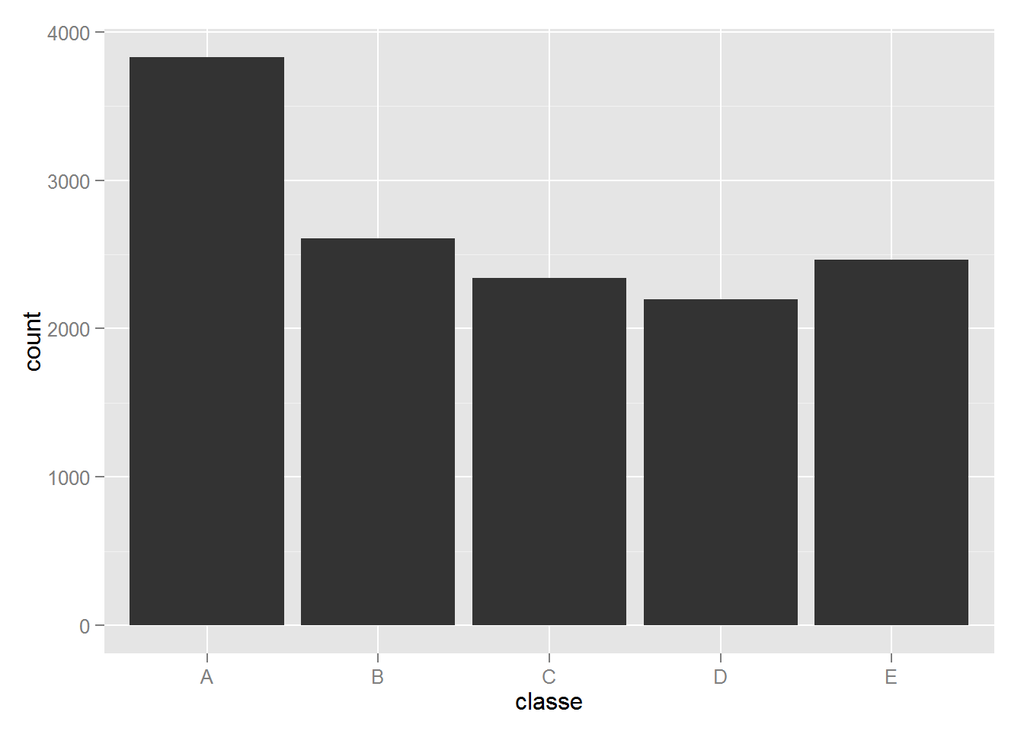

```r
ggplot(data = training5, aes(x = classe)) + geom_histogram()
```

### Build the Model

This analysis uses the Random Forest algorithm, which tends to be reliably accurate and is not significanly biased by correlated covariates or outliers. The model will incorporate all 53 covariates from the cleaned dataset, as indicated in the summary table above. The model will be trained on the training data set, using 5-fold cross-validation, and the number of trees will be set at 250.

```r
train_rf <- trainControl(method = "cv", 5)
rf_mod <- train(classe ~ ., method = "rf", data = training5, trControl = train_rf, ntree = 250)
```

The final model, shown below, has and out-of-bag estimated error rate less than 1%.

```r
rf_mod$finalModel
```

```
##
## Call:
##  randomForest(x = x, y = y, ntree = 250, mtry = param$mtry)
##                Type of random forest: classification
##                      Number of trees: 250
## No. of variables tried at each split: 29
##
##         OOB estimate of  error rate: 0.79%
## Confusion matrix:
##      A    B    C    D    E class.error
## A 3819    7    1    0    2 0.002611648
## B   19 2582    7    0    0 0.009969325
## C    0   17 2314    9    0 0.011111111
## D    0    3   21 2172    2 0.011828935
## E    0    0    8   10 2445 0.007308161
```

### Predict the Outcome

```r
rf_pred <- predict(rf_mod, testing5)
confusionMatrix(rf_pred, testing5$classe)
```

```
## Confusion Matrix and Statistics
##
##           Reference
## Prediction    A    B    C    D    E
##          A 1640    7    0    0    0
##          B    1 1102    6    0    0
##          C    1    1 1005   12    1
##          D    0    0    1  937    5
##          E    0    0    0    0 1059
##
## Overall Statistics
##
##                Accuracy : 0.9939
##                  95% CI : (0.9916, 0.9958)
##     No Information Rate : 0.2842
##     P-Value [Acc > NIR] : < 2.2e-16
##
##                   Kappa : 0.9923
##  Mcnemar's Test P-Value : NA
##
## Statistics by Class:
##
##                      Class: A Class: B Class: C Class: D Class: E
## Sensitivity            0.9988   0.9928   0.9931   0.9874   0.9944
## Specificity            0.9983   0.9985   0.9969   0.9988   1.0000
## Pos Pred Value         0.9957   0.9937   0.9853   0.9936   1.0000
## Neg Pred Value         0.9995   0.9983   0.9985   0.9975   0.9987
## Prevalence             0.2842   0.1921   0.1751   0.1642   0.1843
## Detection Rate         0.2838   0.1907   0.1739   0.1622   0.1833
## Detection Prevalence   0.2850   0.1919   0.1765   0.1632   0.1833
## Balanced Accuracy      0.9985   0.9956   0.9950   0.9931   0.9972
```